# How Do We Know: A Study of Excess Deaths of COVID-19

By Joshua Williams

# Introduction

Is there a way to confirm a pandemic that without trusting the number of reported deaths attributed to Covid-19? Instead of looking at the *stated causes* of deaths, Epidemiologists instead measure the *total* number of deaths In an epidemic, more people die than would otherwise in a usual year. However, if some entity fabricated the pandemic, we would expect no statistically different changes in the number of deaths in a given year.

Each subplot represents data over the same range of time, even though the y-axes are not scaled uniformly scaled. Because the total population, and consequently total deaths, can vary dramatically from state to state, I adjusted scales of the y-axes to elucidate the differences visually. Specifically, the y-axis limits contrast the differences between 2020 and the previous years.

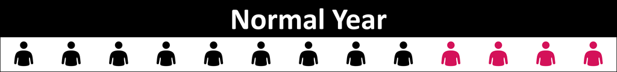

In a theoretical normal year, the number of people who die in a large nation should be fairly predictable. This follows from the law of large numbers

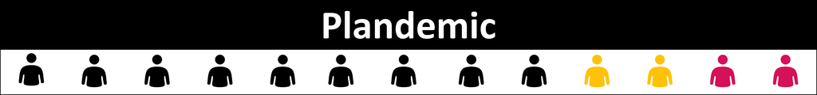

In a theoretical plandemic, we observe how total deaths would look. The same number of people should die, but some of them will be apportioned to deaths by a fake disease

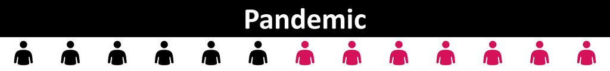

Here we see how the total deaths in theoretical pandemic should appear is how total deaths look in a real pandemic. We expect more people to die during a pandemic, so we should see an increase in the total number of deaths.

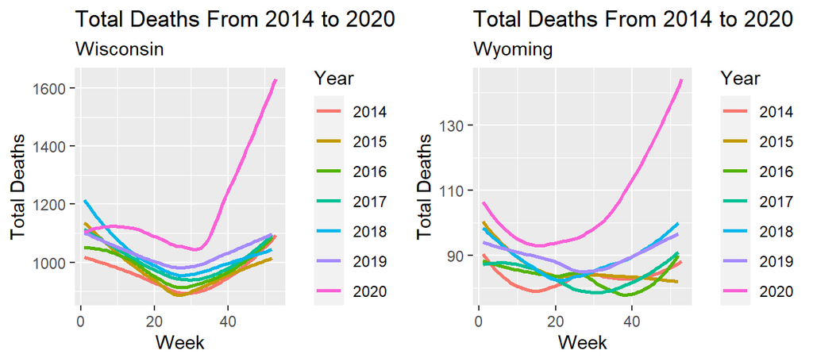

[figure not shown]

## Errata: North Carolina

I asked my statistics professor about the curious case of North Carolina. He noted that, unlike all other subplots, the y-axis includes negative numbers. Since it is not possible to have negative deaths, we knew that something must be wrong with either the code or the data. Upon further analysis, it seemed that the CDC data from which the plots came did not have complete data.

# Conclusion

Since we saw an increase in the total number of deaths, to continue denying the existence of a pandemic, Alice must move the goalposts and re-define her rationale for belief. She must now believe that there is **(1)** there is a way to falsify death certificates to fake the total number of deaths recorded at county, state, and federal levels, or **(2)** there is some other cause to explain the number of deaths, ideally in such a way that explains the correlation between total excess deaths and the deaths attributed to COVID-19.